# tianchi_music

### 导出到csv文件

dataframe可以使用to_csv方法方便地导出到csv文件中，如果数据中含有中文，一般encoding指定为”utf-8″,否则导出时程序会因为不能识别相应的字符串而抛出异常，index指定为False表示不用导出dataframe的index数据。

df.to_csv(file_path, encoding='utf-8', index=False)

```python
import pandas as pd
import numpy as np
import matplotlib.pyplot as plt
import matplotlib
matplotlib.style.use('ggplot')
%pylab inline
```

### 数据格式-用户行为表（mars_tianchi_user_actions）

user_id String 用户唯一标识 7063b3d0c075a4d276c5f06f4327cf4a

song_id String 歌曲唯一标识 effb071415be51f11e845884e67c0f8c

gmt_create String 用户播放时间（unix时间戳表示）精确到小时 1426406400

action_type String 行为类型：1，播放；2，下载，3，收藏 1

Ds String 记录收集日（分区） 20150315

```python
df_user_actions = pd.read_csv('./data/mars_tianchi_user_actions.csv', header = None, names = ('user_id', 'song_id', 'gmt_create', 'action_type', 'Ds'))
```

```python
df_user_actions
```

|  | user_id | song_id | gmt_create | action_type | Ds |
| --- | --- | --- | --- | --- | --- |
| 0 | 7063b3d0c075a4d276c5f06f4327cf4a | effb071415be51f11e845884e67c0f8c | 1426406400 | 1 | 20150315 |
| 1 | 0db66c0dd3993fd3504bb98c3beb15b3 | f87ff481d85d2f95335ab602f38a7655 | 1426417200 | 1 | 20150315 |
| 2 | f8c065dc140ec74c6e44144164e618e3 | 8a27d9a6c59628c991c154e8d93f412e | 1426406400 | 2 | 20150315 |
| 3 | 2c6082cf0d68e244f2a10325e8d1b85b | ecea5fe33e6817d09c395f2910479728 | 1426417200 | 1 | 20150315 |
| 4 | 2c6082cf0d68e244f2a10325e8d1b85b | 31a3d0420d89c9b121bb55dbdbbeda6b | 1426417200 | 1 | 20150315 |
| 5 | 2c6082cf0d68e244f2a10325e8d1b85b | 096e604f7b152fad0246ae731ed8ca73 | 1426417200 | 1 | 20150315 |
| 6 | da87f512eaa2465a6f3bc3c1392a3ff3 | 5a7d9d75b898cd1b19ef6941cc1ddccf | 1426348800 | 1 | 20150315 |
| 7 | 51cecc193b9b7d0478904cd99999fcb4 | 8a103bd3a3295fbf9b3c3bf7972db299 | 1426381200 | 2 | 20150315 |
| 8 | 5c150198fbf8fd3a872ba56ee0e82757 | 17e90c7b3b7ebbe4b47344fcfab2fa7a | 1426359600 | 1 | 20150315 |
| 9 | bafdea952000d147ac13837c408f3540 | 8a27d9a6c59628c991c154e8d93f412e | 1426348800 | 2 | 20150315 |
| 10 | 3e1947c25abf796f243efe9091e13765 | 8a27d9a6c59628c991c154e8d93f412e | 1426388400 | 1 | 20150315 |
| 11 | 7c72f3c49e7c32b688c05895c3337cf6 | 11b6e28c7cd0f16a1e1e7afb01013ff6 | 1426428000 | 2 | 20150315 |
| 12 | 27a608850b1fffe33c3229116112ca71 | ad2fcd743dbb8c53c6ccea59ef006dfc | 1426406400 | 1 | 20150315 |
| 13 | a3998d861f31ecaa48c5a8896869e53d | 8a27d9a6c59628c991c154e8d93f412e | 1426381200 | 1 | 20150315 |
| 14 | 98862006b8c1b7378606652e96db452d | c2c03245b6f8460316fd252f1a2d9e4a | 1426395600 | 1 | 20150315 |
| 15 | 2d5e3250752aa41f545d74e597900528 | 48832614076d8cded18f44ca5a8fd56b | 1426381200 | 1 | 20150315 |
| 16 | d6535c66f278468d8fad7e0a840178d1 | f3ca7994a5e9f200e7dd8273688b79e9 | 1426388400 | 2 | 20150315 |
| 17 | bcbbacf9df0f2e1911eb5171dd92b9a6 | 8234f6562e44ef26622a03c01a554f76 | 1426417200 | 1 | 20150315 |
| 18 | ed8787d6532f5a2245ea7bc470d5a4f1 | ddc5c0d45d1ca96a58ad48343040c761 | 1426348800 | 1 | 20150315 |
| 19 | 6ddc712848098b048a1d10fc22e01df6 | c880db958bcb5efec70edd60cb2739de | 1426352400 | 1 | 20150315 |
| 20 | cc8fd21fa10f058a1f43a2f6106199f1 | 1af9707e7f29d6a977f76e3e62eb4ec8 | 1426410000 | 1 | 20150315 |
| 21 | f6ef2623a6804af88b51764d63e81d1f | 8a27d9a6c59628c991c154e8d93f412e | 1426381200 | 1 | 20150315 |
| 22 | 4bf2c26fbaa488a60b20a86ca8b47518 | 8a27d9a6c59628c991c154e8d93f412e | 1426413600 | 1 | 20150315 |
| 23 | 3dfd3e98827ce92e10de3f9e0ab9b2d9 | 12e449b15a0dcc0611215712dda8b399 | 1426410000 | 1 | 20150315 |
| 24 | 08b087618bad921e1d1bb46dfd1b68ba | 5fc3eae9ac61fceef0b89d6a95e294f1 | 1426395600 | 1 | 20150315 |
| 25 | 15401f388c0ce0f0a37b86893ec80a85 | aed2f6db07d0b66b8dcb41b0334a6f36 | 1426402800 | 1 | 20150315 |
| 26 | bbc0e6133b9470922802ef1ef7f6a1e1 | 8a27d9a6c59628c991c154e8d93f412e | 1426384800 | 1 | 20150315 |
| 27 | 76b01ac34338f841b9df017ffb6a9c51 | 46e9d5f148610d3b7f379f9d61c2958b | 1426428000 | 1 | 20150315 |
| 28 | e17d560b05e055c29710c6c0cb1d9441 | c75eb8b7ef3c0fb605a501ca6bbed98e | 1426424400 | 1 | 20150315 |
| 29 | 13b2d309bd281e4c84d577612f28d063 | 2660daee2f1db48a100b359b5a011287 | 1426420800 | 1 | 20150315 |
| ... | ... | ... | ... | ... | ... |
| 5652202 | ad24f89e3a4baacf61d38466376f6987 | 0621fb4e29424e17728efe7e8453984a | 1425211200 | 2 | 20150301 |
| 5652203 | ad24f89e3a4baacf61d38466376f6987 | 1be824de5257bd6811c7b800ffe1ba89 | 1425211200 | 2 | 20150301 |
| 5652204 | ec94ad9037d92f4749bb6790e959757c | 1689d15bfc70e7333db3081acef02a61 | 1425222000 | 1 | 20150301 |
| 5652205 | 295182c5b3e9183cd138903a00bfae14 | 58822c17781ca4f9e25dfa358a7eef5e | 1425214800 | 1 | 20150301 |
| 5652206 | 25f77c71c4bc5e85a52898edf3cb9366 | 0081e9a35207457455b6703178a79303 | 1425196800 | 1 | 20150301 |
| 5652207 | 16cc017b477a8de7e19c9e7ec0fb21a8 | 608e28d2a8e3a98d0d84953b382c2218 | 1425214800 | 1 | 20150301 |
| 5652208 | 16cc017b477a8de7e19c9e7ec0fb21a8 | 608e28d2a8e3a98d0d84953b382c2218 | 1425214800 | 1 | 20150301 |
| 5652209 | c30b8fbad79c15516b4de54c8d473a84 | c880db958bcb5efec70edd60cb2739de | 1425168000 | 1 | 20150301 |
| 5652210 | 2da1a6bcff952998f54d0bea21508197 | 8a18c3e71ee2ac510f5391e2bc815c9f | 1425168000 | 1 | 20150301 |
| 5652211 | 936b15122b1400bce73c18d3863d5393 | f87ff481d85d2f95335ab602f38a7655 | 1425214800 | 1 | 20150301 |
| 5652212 | 3380340fae6ec1a8cd8b839efa118011 | 83e4a2081d89e6f234b59eec8c388ce4 | 1425222000 | 1 | 20150301 |
| 5652213 | 3380340fae6ec1a8cd8b839efa118011 | ddbdea92d9d7d691a4783a096cbc1139 | 1425222000 | 1 | 20150301 |
| 5652214 | 3380340fae6ec1a8cd8b839efa118011 | 31a3d0420d89c9b121bb55dbdbbeda6b | 1425218400 | 1 | 20150301 |
| 5652215 | 3380340fae6ec1a8cd8b839efa118011 | e9eef698fea742b4edb127b737835eed | 1425218400 | 1 | 20150301 |
| 5652216 | 3380340fae6ec1a8cd8b839efa118011 | 6d2a966a9be00d734f636f6f17d94959 | 1425222000 | 1 | 20150301 |
| 5652217 | 3380340fae6ec1a8cd8b839efa118011 | 33fe12fe79b4256660f35e1977b62a66 | 1425218400 | 2 | 20150301 |
| 5652218 | 3380340fae6ec1a8cd8b839efa118011 | bd555393220ed120bafa79e6f6022230 | 1425218400 | 2 | 20150301 |
| 5652219 | 3380340fae6ec1a8cd8b839efa118011 | ecea5fe33e6817d09c395f2910479728 | 1425218400 | 2 | 20150301 |
| 5652220 | 3380340fae6ec1a8cd8b839efa118011 | bd555393220ed120bafa79e6f6022230 | 1425218400 | 1 | 20150301 |
| 5652221 | 3380340fae6ec1a8cd8b839efa118011 | 33fe12fe79b4256660f35e1977b62a66 | 1425218400 | 1 | 20150301 |
| 5652222 | 3380340fae6ec1a8cd8b839efa118011 | 0f702ec7ce36d727280eae018032b382 | 1425218400 | 2 | 20150301 |
| 5652223 | 3380340fae6ec1a8cd8b839efa118011 | ecea5fe33e6817d09c395f2910479728 | 1425218400 | 1 | 20150301 |
| 5652224 | 3380340fae6ec1a8cd8b839efa118011 | 4f6f592f3a35677965220d55a394bb3e | 1425222000 | 1 | 20150301 |
| 5652225 | 3380340fae6ec1a8cd8b839efa118011 | d7d43faeb43ccea9fe57a250406fc547 | 1425222000 | 1 | 20150301 |
| 5652226 | 3380340fae6ec1a8cd8b839efa118011 | 0f702ec7ce36d727280eae018032b382 | 1425218400 | 1 | 20150301 |
| 5652227 | 3380340fae6ec1a8cd8b839efa118011 | 096e604f7b152fad0246ae731ed8ca73 | 1425218400 | 2 | 20150301 |
| 5652228 | 3380340fae6ec1a8cd8b839efa118011 | 096e604f7b152fad0246ae731ed8ca73 | 1425218400 | 1 | 20150301 |
| 5652229 | 80bf62e4e055088174746d378d1f1ae7 | 0621fb4e29424e17728efe7e8453984a | 1425218400 | 2 | 20150301 |
| 5652230 | 80bf62e4e055088174746d378d1f1ae7 | 1be824de5257bd6811c7b800ffe1ba89 | 1425218400 | 2 | 20150301 |
| 5652231 | 80bf62e4e055088174746d378d1f1ae7 | 874f9a7d5bcef6115f6564f84d4743b7 | 1425218400 | 2 | 20150301 |

5652232 rows × 5 columns

```python
# user id count
users = df_user_actions['user_id']
print len(set(users))
```

```
349946
```

### 数据格式-歌曲艺人（mars_tianchi_songs）

song_idString 歌曲唯一标识 c81f89cf7edd24930641afa2e411b09c

artist_id String 歌曲所属的艺人Id 03c6699ea836decbc5c8fc2dbae7bd3b

publish_time String 歌曲发行时间，精确到天 20150325

song_init_plays String 歌曲的初始播放数，表明该歌曲的初始热度 0

Language String 数字表示1,2,3… 100

Gender String 1,2,3 1

```python
df_song_info = pd.read_csv('./data/mars_tianchi_songs.csv', header = None, names = ('song_id', 'artist_id', 'public_time', 'popular', 'language', 'gender'))
```

```python
df_song_info
```

|  | song_id | artist_id | public_time | popular | language | gender |
| --- | --- | --- | --- | --- | --- | --- |
| 0 | af0e153c72bf63e21bb42702ef0d7726 | 0c80008b0a28d356026f4b1097041689 | 20120512 | 11360 | 2 | 1 |
| 1 | 0919b5ed4ce2649f61bcc6c21fadab12 | 0c80008b0a28d356026f4b1097041689 | 20121224 | 2018 | 2 | 1 |
| 2 | 8a0777df37bf6a0f3384d63a47d4d21b | 0c80008b0a28d356026f4b1097041689 | 20111206 | 4825 | 2 | 1 |
| 3 | b61bc45712ee40c3f4a37dd4d063ad52 | 0c80008b0a28d356026f4b1097041689 | 20130522 | 5502 | 2 | 1 |
| 4 | a2fbe29da3a760d7467b8a7b3247a9c8 | 0c80008b0a28d356026f4b1097041689 | 20130522 | 2990 | 2 | 1 |
| 5 | b5e92cb9ff2126189c19305cf148b25d | 0c80008b0a28d356026f4b1097041689 | 20130522 | 5701 | 2 | 1 |
| 6 | f50884b22708157e285fd0ea32eeb448 | 0c80008b0a28d356026f4b1097041689 | 20130522 | 2169 | 2 | 1 |
| 7 | e84ba26cd51b4fcd0811a89957f7bec4 | 0c80008b0a28d356026f4b1097041689 | 20121224 | 2151 | 2 | 1 |
| 8 | aa3d273a62dbc392654877fdcdae41b7 | 0c80008b0a28d356026f4b1097041689 | 20111123 | 27560 | 2 | 1 |
| 9 | 3e721589da31c018bc2f7541e995f795 | 0c80008b0a28d356026f4b1097041689 | 20111106 | 445443 | 2 | 1 |
| 10 | bfe32f41f48bbaf37f5f69c934e097e6 | 0c80008b0a28d356026f4b1097041689 | 20110421 | 16086 | 4 | 1 |
| 11 | 20f35a9e2d910cf835357bc919cdb91f | 0c80008b0a28d356026f4b1097041689 | 20111206 | 2015 | 2 | 1 |
| 12 | 5115e29539681a96cc91fe0ad194abdc | 0c80008b0a28d356026f4b1097041689 | 20111206 | 2396 | 2 | 1 |
| 13 | 1019308763a9a93e529a4ee155d4cfca | 0c80008b0a28d356026f4b1097041689 | 20121224 | 947 | 2 | 1 |
| 14 | 84bd30a7d4c2d89887b8fc309c63c6df | 0c80008b0a28d356026f4b1097041689 | 20121224 | 4230 | 2 | 1 |
| 15 | 15a7480157bdc5ece13bbcf4f4a368a7 | 0c80008b0a28d356026f4b1097041689 | 20130522 | 8864 | 2 | 1 |
| 16 | fb093a12ee69ed7dca64c705599b1670 | 0c80008b0a28d356026f4b1097041689 | 20111206 | 5143 | 2 | 1 |
| 17 | 1ddfc1c7e0dbdd6bbc82764d27614bb4 | 0c80008b0a28d356026f4b1097041689 | 20121224 | 2470 | 2 | 1 |
| 18 | e22d6a72a0661aeff027a65b49745672 | 0c80008b0a28d356026f4b1097041689 | 20110504 | 0 | 2 | 1 |
| 19 | f7d86581a5fdceecaf9c907b174998f2 | 0c80008b0a28d356026f4b1097041689 | 20130522 | 10520 | 2 | 1 |
| 20 | 493fac46c62c7527a84bbed25408ba64 | 0c80008b0a28d356026f4b1097041689 | 20111123 | 17555 | 2 | 1 |
| 21 | 3c21b8b3531aa2bdff45e48d10c1a374 | 0c80008b0a28d356026f4b1097041689 | 20111111 | 45911 | 2 | 1 |
| 22 | 4a1e40bf455cd87191077093d3476960 | 0c80008b0a28d356026f4b1097041689 | 20120629 | 13728 | 100 | 1 |
| 23 | 5af9cb7b11561eb29d4119944c746f29 | 0c80008b0a28d356026f4b1097041689 | 20110421 | 144058 | 4 | 1 |
| 24 | 231cd3b7910b88605b300f40b71af65c | 0c80008b0a28d356026f4b1097041689 | 20110421 | 90558 | 4 | 1 |
| 25 | a7312f08d0d4071a34f74a74f646e74f | 0c80008b0a28d356026f4b1097041689 | 20111224 | 5459 | 2 | 1 |
| 26 | 0399c5b692cc62439583133e0d523799 | 0c80008b0a28d356026f4b1097041689 | 20130522 | 2077 | 2 | 1 |
| 27 | 070e4db7efb85ddf12c77240a4990fb6 | 0c80008b0a28d356026f4b1097041689 | 20120629 | 7246 | 100 | 1 |
| 28 | 7ee5b3d1c67b36a01b2a56bf652401f8 | 0c80008b0a28d356026f4b1097041689 | 20111206 | 2356 | 2 | 1 |
| 29 | 04b692aa2b635ea4f884b92b6bdb083a | 0c80008b0a28d356026f4b1097041689 | 20111206 | 5257 | 2 | 1 |
| ... | ... | ... | ... | ... | ... | ... |
| 10812 | 6bea99ee6f13b6838bbcd07cc3dbfc85 | f6e0f05fde7637afb8f8bc6bda74ca24 | 20051026 | 62940 | 3 | 1 |
| 10813 | dad2a3541ee6f3ad0fc746ad13886c73 | f6e0f05fde7637afb8f8bc6bda74ca24 | 20111125 | 6560 | 3 | 1 |
| 10814 | c73889c841ba9310eb86490b0d3d24ce | f6e0f05fde7637afb8f8bc6bda74ca24 | 20051026 | 3068 | 3 | 1 |
| 10815 | 5b5f950311c055d984c335212e9470d2 | f6e0f05fde7637afb8f8bc6bda74ca24 | 20051026 | 2682 | 3 | 1 |
| 10816 | 94e780bf45c317652d763a71ff0bc6ab | f6e0f05fde7637afb8f8bc6bda74ca24 | 20051026 | 2268 | 3 | 1 |
| 10817 | eed6a0870472ef534ba6218ae554fcc0 | f6e0f05fde7637afb8f8bc6bda74ca24 | 20111125 | 8855 | 3 | 1 |
| 10818 | b08b2bb148a8025ebc9daff47ac6d071 | f6e0f05fde7637afb8f8bc6bda74ca24 | 20130701 | 33969 | 3 | 1 |
| 10819 | 2ea2fc47ffcb373452b89ca031fc03e2 | f6e0f05fde7637afb8f8bc6bda74ca24 | 20130701 | 4819 | 3 | 1 |
| 10820 | 90291ada3abe9d092527003ad81a68e3 | f6e0f05fde7637afb8f8bc6bda74ca24 | 20040517 | 4655 | 3 | 1 |
| 10821 | 409d601876c27360ff47bd48b6fe5246 | f6e0f05fde7637afb8f8bc6bda74ca24 | 20111118 | 6694 | 3 | 1 |
| 10822 | 635e52a8859bd48a63c3241b8fce29a4 | f6e0f05fde7637afb8f8bc6bda74ca24 | 20040517 | 622 | 3 | 1 |
| 10823 | 2ead6a9e503064b012ebd9dba1866527 | f6e0f05fde7637afb8f8bc6bda74ca24 | 20111125 | 24546 | 3 | 1 |
| 10824 | 8ce21c0b2e7d730ca003d0abf9fb2833 | f6e0f05fde7637afb8f8bc6bda74ca24 | 20091007 | 3433 | 3 | 1 |
| 10825 | 5b2f08e955ab057fc6ae5560ab21472d | f6e0f05fde7637afb8f8bc6bda74ca24 | 20091007 | 6541 | 3 | 1 |
| 10826 | 52149ffd01cf8419b79979be6006c544 | f6e0f05fde7637afb8f8bc6bda74ca24 | 20091007 | 22281 | 3 | 1 |
| 10827 | 15caa9a7aa5a648ecfacee64c42926e9 | f6e0f05fde7637afb8f8bc6bda74ca24 | 20111125 | 14328 | 3 | 1 |
| 10828 | 1b328c38a9e4873e225bb46309a1ad84 | f6e0f05fde7637afb8f8bc6bda74ca24 | 20040517 | 1576 | 3 | 1 |
| 10829 | c531a3fab75d4f624c7ad5682ac9b14e | f6e0f05fde7637afb8f8bc6bda74ca24 | 20040517 | 3099 | 3 | 1 |
| 10830 | a20bdf3e2cebf6a6cf6a9b72d821d950 | f6e0f05fde7637afb8f8bc6bda74ca24 | 20080820 | 756 | 3 | 1 |
| 10831 | 5461be7f9c00a8b6d5e7cdd6dba8b087 | f6e0f05fde7637afb8f8bc6bda74ca24 | 20051026 | 4618 | 3 | 1 |
| 10832 | d873a296d67e8a9cb4b1f7e73b686a8f | f6e0f05fde7637afb8f8bc6bda74ca24 | 20091007 | 4876 | 3 | 1 |
| 10833 | 363575dc31fc4a9a91f078ca3ce96b2a | f6e0f05fde7637afb8f8bc6bda74ca24 | 20111118 | 778 | 3 | 1 |
| 10834 | ffffb8ee31ac747d06dce78e8b328a5c | f6e0f05fde7637afb8f8bc6bda74ca24 | 20130701 | 32948 | 3 | 1 |
| 10835 | 09ae793cae7c4e355800cd2320cb6c42 | f6e0f05fde7637afb8f8bc6bda74ca24 | 20130701 | 393173 | 3 | 1 |
| 10836 | dec79d95fb5fcec852ab62fe2c9ad918 | f6e0f05fde7637afb8f8bc6bda74ca24 | 20130701 | 43621 | 3 | 1 |
| 10837 | 2338386bb749f660d075b433ede90553 | f6e0f05fde7637afb8f8bc6bda74ca24 | 20080820 | 1081 | 3 | 1 |
| 10838 | 05957aa98b28658a9fb8b28d0a6001d6 | f6e0f05fde7637afb8f8bc6bda74ca24 | 20040517 | 2236 | 3 | 1 |
| 10839 | 2882b5ab4dd32f071e94ce593acc6ba7 | f6e0f05fde7637afb8f8bc6bda74ca24 | 20111125 | 1355 | 3 | 1 |
| 10840 | 3fc1e1389fb7c5f6e9df22f12e1bca64 | f6e0f05fde7637afb8f8bc6bda74ca24 | 20111125 | 5867 | 3 | 1 |
| 10841 | d14f0ff9d579e9400c811b7cba8f947d | f6e0f05fde7637afb8f8bc6bda74ca24 | 20130701 | 53985 | 3 | 1 |

10842 rows × 6 columns

统计艺人总数

```python
artists = df_song_info['artist_id']

artists = set(artists)

print len(artists)
```

```
50
```

只有50个艺人

DataFrame 对象的标准切片语法为：.ix[::,::]。ix 对象可以接受两套切片，分别为行（axis=0）和列（axis=1）的方向

不使用 ix时：

索引时，选取的是列 切片时，选取的是行

# 尝试统计数据

## 1.从歌手角度统计

```python
artists = {}
for i in range(0, df_song_info.shape[0]):
    artist = df_song_info.iloc[i]['artist_id']
    song = df_song_info.iloc[i]['song_id']
    if artist not in artists:
        artists[artist] = []
    artists[artist].append(song)

song_id = list(set(df_song_info['song_id']))
# songs = {}
# for i in song_id:
#     songs[i] = {}

# 歌曲总量
print len(song_id)
```

```
10842
```

```python
# song_info = {}
# for i in range(0, df_user_actions.shape[0]):
#     info = df_user_actions.iloc[i]
#     song = info['song_id']
#     action = info['action_type']
#     time = info['Ds']
#     if song not in songs:
#         print 'wrong!\n', info
#         break
```

**统计每首歌的每日播放量**

```python
dates =  list(set(df_user_actions['Ds']))
dates.sort()
print len(dates)
```

```
183
```

```python
# import time

# time_start = time.asctime(time.localtime(time.time()))
# fp = open('./songs.txt', 'w')
# for song in song_id[:50]:
#     song_list = df_user_actions[df_user_actions.song_id == song]
#     content = ''
#     for date in dates:
#         song_today = song_list[song_list.Ds == date]
#         play = len(song_today[song_today.action_type == 1])
#         download = len(song_today[song_today.action_type == 2])
#         like = len(song_today[song_today.action_type == 3])
#         content += "%s,%d,%d,%d,%d\n" % (song,date,play,download,like)
#     fp.write(content)
# #         count = count + play + like + download
# fp.write('done!\n')
# fp.close()
# time_end = time.asctime(time.localtime(time.time()))
# time_stamp = str(time.time())
# fp = open('./done'+time_stamp+'.txt', 'w')
# fp.write(str(time_start)+'\n')
# fp.write(str(time_end)+'\n')
# fp.close()
```

```python
df_songs_by_day = pd.read_csv('./data/songs_by_day.csv', header = None, names = ('song_id', 'date', 'play', 'download', 'like'))
```

```python
df_songs_by_day.describe()
```

|  | date | play | download | like |
| --- | --- | --- | --- | --- |
| count | 1984086.000000 | 1984086.000000 | 1984086.000000 | 1984086.000000 |
| mean | 20150564.934426 | 2.410986 | 0.409472 | 0.028326 |
| std | 170.934428 | 21.037990 | 3.332696 | 0.356057 |
| min | 20150301.000000 | 0.000000 | 0.000000 | 0.000000 |
| 25% | 20150415.000000 | 0.000000 | 0.000000 | 0.000000 |
| 50% | 20150531.000000 | 0.000000 | 0.000000 | 0.000000 |
| 75% | 20150716.000000 | 0.000000 | 0.000000 | 0.000000 |
| max | 20150830.000000 | 3767.000000 | 708.000000 | 116.000000 |

```python
df_songs_by_day
```

|  | song_id | date | play | download | like |
| --- | --- | --- | --- | --- | --- |
| 0 | b4e23c8cca36326a787763652bdcfb4f | 20150301 | 0 | 1 | 0 |
| 1 | b4e23c8cca36326a787763652bdcfb4f | 20150302 | 0 | 0 | 0 |
| 2 | b4e23c8cca36326a787763652bdcfb4f | 20150303 | 0 | 0 | 0 |
| 3 | b4e23c8cca36326a787763652bdcfb4f | 20150304 | 0 | 0 | 0 |
| 4 | b4e23c8cca36326a787763652bdcfb4f | 20150305 | 0 | 0 | 0 |
| 5 | b4e23c8cca36326a787763652bdcfb4f | 20150306 | 0 | 0 | 0 |
| 6 | b4e23c8cca36326a787763652bdcfb4f | 20150307 | 0 | 0 | 0 |
| 7 | b4e23c8cca36326a787763652bdcfb4f | 20150308 | 0 | 0 | 0 |
| 8 | b4e23c8cca36326a787763652bdcfb4f | 20150309 | 0 | 0 | 0 |
| 9 | b4e23c8cca36326a787763652bdcfb4f | 20150310 | 0 | 0 | 0 |
| 10 | b4e23c8cca36326a787763652bdcfb4f | 20150311 | 0 | 0 | 0 |
| 11 | b4e23c8cca36326a787763652bdcfb4f | 20150312 | 0 | 0 | 0 |
| 12 | b4e23c8cca36326a787763652bdcfb4f | 20150313 | 0 | 0 | 0 |
| 13 | b4e23c8cca36326a787763652bdcfb4f | 20150314 | 1 | 0 | 0 |
| 14 | b4e23c8cca36326a787763652bdcfb4f | 20150315 | 0 | 0 | 0 |
| 15 | b4e23c8cca36326a787763652bdcfb4f | 20150316 | 0 | 0 | 0 |
| 16 | b4e23c8cca36326a787763652bdcfb4f | 20150317 | 0 | 0 | 0 |
| 17 | b4e23c8cca36326a787763652bdcfb4f | 20150318 | 0 | 0 | 0 |
| 18 | b4e23c8cca36326a787763652bdcfb4f | 20150319 | 0 | 0 | 0 |
| 19 | b4e23c8cca36326a787763652bdcfb4f | 20150320 | 0 | 0 | 0 |
| 20 | b4e23c8cca36326a787763652bdcfb4f | 20150321 | 0 | 0 | 0 |
| 21 | b4e23c8cca36326a787763652bdcfb4f | 20150322 | 0 | 0 | 0 |
| 22 | b4e23c8cca36326a787763652bdcfb4f | 20150323 | 0 | 0 | 0 |
| 23 | b4e23c8cca36326a787763652bdcfb4f | 20150324 | 0 | 0 | 0 |
| 24 | b4e23c8cca36326a787763652bdcfb4f | 20150325 | 0 | 0 | 0 |
| 25 | b4e23c8cca36326a787763652bdcfb4f | 20150326 | 0 | 0 | 0 |
| 26 | b4e23c8cca36326a787763652bdcfb4f | 20150327 | 0 | 1 | 0 |
| 27 | b4e23c8cca36326a787763652bdcfb4f | 20150328 | 0 | 1 | 0 |
| 28 | b4e23c8cca36326a787763652bdcfb4f | 20150329 | 0 | 0 | 0 |
| 29 | b4e23c8cca36326a787763652bdcfb4f | 20150330 | 0 | 0 | 0 |
| ... | ... | ... | ... | ... | ... |
| 1984056 | d60052fdab257521a3c740debf885d8d | 20150801 | 0 | 0 | 0 |
| 1984057 | d60052fdab257521a3c740debf885d8d | 20150802 | 0 | 0 | 0 |
| 1984058 | d60052fdab257521a3c740debf885d8d | 20150803 | 0 | 0 | 0 |
| 1984059 | d60052fdab257521a3c740debf885d8d | 20150804 | 0 | 0 | 0 |
| 1984060 | d60052fdab257521a3c740debf885d8d | 20150805 | 2 | 0 | 0 |
| 1984061 | d60052fdab257521a3c740debf885d8d | 20150806 | 0 | 0 | 0 |
| 1984062 | d60052fdab257521a3c740debf885d8d | 20150807 | 0 | 0 | 0 |
| 1984063 | d60052fdab257521a3c740debf885d8d | 20150808 | 0 | 0 | 0 |
| 1984064 | d60052fdab257521a3c740debf885d8d | 20150809 | 0 | 0 | 0 |
| 1984065 | d60052fdab257521a3c740debf885d8d | 20150810 | 0 | 0 | 0 |
| 1984066 | d60052fdab257521a3c740debf885d8d | 20150811 | 0 | 0 | 0 |
| 1984067 | d60052fdab257521a3c740debf885d8d | 20150812 | 0 | 0 | 0 |
| 1984068 | d60052fdab257521a3c740debf885d8d | 20150813 | 2 | 0 | 0 |
| 1984069 | d60052fdab257521a3c740debf885d8d | 20150814 | 0 | 0 | 0 |
| 1984070 | d60052fdab257521a3c740debf885d8d | 20150815 | 0 | 0 | 0 |
| 1984071 | d60052fdab257521a3c740debf885d8d | 20150816 | 0 | 0 | 0 |
| 1984072 | d60052fdab257521a3c740debf885d8d | 20150817 | 0 | 0 | 0 |
| 1984073 | d60052fdab257521a3c740debf885d8d | 20150818 | 0 | 0 | 0 |
| 1984074 | d60052fdab257521a3c740debf885d8d | 20150819 | 0 | 0 | 0 |
| 1984075 | d60052fdab257521a3c740debf885d8d | 20150820 | 0 | 0 | 0 |
| 1984076 | d60052fdab257521a3c740debf885d8d | 20150821 | 0 | 0 | 0 |
| 1984077 | d60052fdab257521a3c740debf885d8d | 20150822 | 0 | 0 | 0 |
| 1984078 | d60052fdab257521a3c740debf885d8d | 20150823 | 0 | 0 | 0 |
| 1984079 | d60052fdab257521a3c740debf885d8d | 20150824 | 0 | 0 | 0 |
| 1984080 | d60052fdab257521a3c740debf885d8d | 20150825 | 0 | 0 | 0 |
| 1984081 | d60052fdab257521a3c740debf885d8d | 20150826 | 0 | 0 | 0 |
| 1984082 | d60052fdab257521a3c740debf885d8d | 20150827 | 0 | 0 | 0 |
| 1984083 | d60052fdab257521a3c740debf885d8d | 20150828 | 0 | 0 | 0 |
| 1984084 | d60052fdab257521a3c740debf885d8d | 20150829 | 0 | 0 | 0 |
| 1984085 | d60052fdab257521a3c740debf885d8d | 20150830 | 1 | 0 | 0 |

1984086 rows × 5 columns

**绘制单首歌曲的日期趋势图**

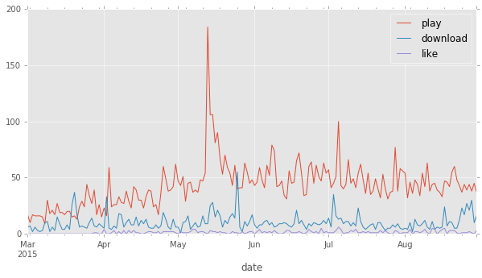

```python
# get the data of a specific song
s = df_songs_by_day[['date', 'play', 'download', 'like']][df_songs_by_day['song_id'] == '3e721589da31c018bc2f7541e995f795']

# create the dates index
s['date'] = pd.date_range('20150301', '20150830').tolist()

s = s.set_index(['date'])

s.plot(figsize = (10,5))
# s.plot()
```

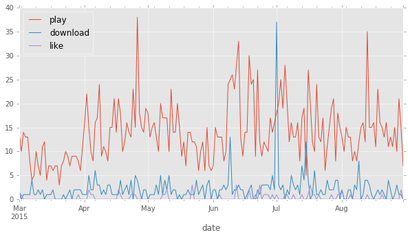

```python
# get the data of a specific song
s = df_songs_by_day[['date', 'play', 'download', 'like']][df_songs_by_day['song_id'] == '09ae793cae7c4e355800cd2320cb6c42']

# create the dates index
s['date'] = pd.date_range('20150301', '20150830').tolist()

s = s.set_index(['date'])

s.plot(figsize = (10,5))
# s.plot()
```

**按照歌手情况进行统计**

```python
# for artist_id in artists:
#     temp = df_songs_by_day[['play', 'download', 'like']][df_songs_by_day['song_id'] == artists[artist_id][0]]
#     temp['date'] = pd.date_range('20150301', '20150830')
#     temp = temp.set_index(['date'])
#     for song_id in artists[artist_id][1:]:
#         temp2 = df_songs_by_day[['play', 'download', 'like']][df_songs_by_day['song_id'] == song_id]
#         temp2['date'] = pd.date_range('20150301', '20150830')
#         temp2 = temp2.set_index(['date'])
#         temp = temp.add(temp2)
#     temp['artist'] = artist_id
#     temp.to_csv('./artists.csv', mode = 'a', encoding='utf-8', header = False)
# print 'done!'
```

```python
df_artists = pd.read_csv('./data/artists.csv', header = None, names = ['date', 'play', 'download', 'like', 'artist_id'])
```

```python
len(set(df_artists['artist_id']))
```

```
50
```

```python
df_artists.describe()
```

|  | play | download | like |
| --- | --- | --- | --- |
| count | 9150.000000 | 9150.000000 | 9150.000000 |
| mean | 522.798142 | 88.789836 | 6.142295 |
| std | 647.251490 | 146.886321 | 9.213115 |
| min | 0.000000 | 0.000000 | 0.000000 |
| 25% | 118.000000 | 17.000000 | 1.000000 |
| 50% | 304.000000 | 43.000000 | 3.000000 |
| 75% | 711.000000 | 96.000000 | 8.000000 |
| max | 8489.000000 | 3136.000000 | 150.000000 |

```python
df_artists
```

|  | date | play | download | like | artist_id |
| --- | --- | --- | --- | --- | --- |
| 0 | 2015-03-01 | 58 | 10 | 0 | e087f8842fe66efa5ccee42ff791e0ca |
| 1 | 2015-03-02 | 99 | 61 | 0 | e087f8842fe66efa5ccee42ff791e0ca |
| 2 | 2015-03-03 | 125 | 84 | 5 | e087f8842fe66efa5ccee42ff791e0ca |
| 3 | 2015-03-04 | 273 | 19 | 0 | e087f8842fe66efa5ccee42ff791e0ca |
| 4 | 2015-03-05 | 172 | 69 | 0 | e087f8842fe66efa5ccee42ff791e0ca |
| 5 | 2015-03-06 | 313 | 46 | 0 | e087f8842fe66efa5ccee42ff791e0ca |
| 6 | 2015-03-07 | 99 | 17 | 0 | e087f8842fe66efa5ccee42ff791e0ca |
| 7 | 2015-03-08 | 132 | 32 | 0 | e087f8842fe66efa5ccee42ff791e0ca |
| 8 | 2015-03-09 | 100 | 16 | 0 | e087f8842fe66efa5ccee42ff791e0ca |
| 9 | 2015-03-10 | 94 | 150 | 0 | e087f8842fe66efa5ccee42ff791e0ca |
| 10 | 2015-03-11 | 74 | 219 | 0 | e087f8842fe66efa5ccee42ff791e0ca |
| 11 | 2015-03-12 | 120 | 83 | 1 | e087f8842fe66efa5ccee42ff791e0ca |
| 12 | 2015-03-13 | 64 | 139 | 0 | e087f8842fe66efa5ccee42ff791e0ca |
| 13 | 2015-03-14 | 88 | 38 | 0 | e087f8842fe66efa5ccee42ff791e0ca |
| 14 | 2015-03-15 | 116 | 6 | 0 | e087f8842fe66efa5ccee42ff791e0ca |
| 15 | 2015-03-16 | 83 | 16 | 0 | e087f8842fe66efa5ccee42ff791e0ca |
| 16 | 2015-03-17 | 96 | 33 | 0 | e087f8842fe66efa5ccee42ff791e0ca |
| 17 | 2015-03-18 | 94 | 4 | 0 | e087f8842fe66efa5ccee42ff791e0ca |
| 18 | 2015-03-19 | 130 | 4 | 0 | e087f8842fe66efa5ccee42ff791e0ca |
| 19 | 2015-03-20 | 196 | 17 | 0 | e087f8842fe66efa5ccee42ff791e0ca |
| 20 | 2015-03-21 | 116 | 7 | 0 | e087f8842fe66efa5ccee42ff791e0ca |
| 21 | 2015-03-22 | 120 | 7 | 0 | e087f8842fe66efa5ccee42ff791e0ca |
| 22 | 2015-03-23 | 243 | 4 | 0 | e087f8842fe66efa5ccee42ff791e0ca |
| 23 | 2015-03-24 | 81 | 8 | 0 | e087f8842fe66efa5ccee42ff791e0ca |
| 24 | 2015-03-25 | 177 | 6 | 0 | e087f8842fe66efa5ccee42ff791e0ca |
| 25 | 2015-03-26 | 63 | 6 | 0 | e087f8842fe66efa5ccee42ff791e0ca |
| 26 | 2015-03-27 | 100 | 24 | 0 | e087f8842fe66efa5ccee42ff791e0ca |
| 27 | 2015-03-28 | 113 | 15 | 1 | e087f8842fe66efa5ccee42ff791e0ca |
| 28 | 2015-03-29 | 94 | 5 | 0 | e087f8842fe66efa5ccee42ff791e0ca |
| 29 | 2015-03-30 | 84 | 31 | 1 | e087f8842fe66efa5ccee42ff791e0ca |
| ... | ... | ... | ... | ... | ... |
| 9120 | 2015-08-01 | 603 | 86 | 8 | 5e2ef5473cbbdb335f6d51dc57845437 |
| 9121 | 2015-08-02 | 585 | 71 | 2 | 5e2ef5473cbbdb335f6d51dc57845437 |
| 9122 | 2015-08-03 | 666 | 77 | 11 | 5e2ef5473cbbdb335f6d51dc57845437 |
| 9123 | 2015-08-04 | 701 | 91 | 5 | 5e2ef5473cbbdb335f6d51dc57845437 |
| 9124 | 2015-08-05 | 683 | 92 | 6 | 5e2ef5473cbbdb335f6d51dc57845437 |
| 9125 | 2015-08-06 | 694 | 76 | 14 | 5e2ef5473cbbdb335f6d51dc57845437 |
| 9126 | 2015-08-07 | 550 | 152 | 5 | 5e2ef5473cbbdb335f6d51dc57845437 |
| 9127 | 2015-08-08 | 547 | 70 | 5 | 5e2ef5473cbbdb335f6d51dc57845437 |
| 9128 | 2015-08-09 | 571 | 111 | 32 | 5e2ef5473cbbdb335f6d51dc57845437 |
| 9129 | 2015-08-10 | 634 | 47 | 2 | 5e2ef5473cbbdb335f6d51dc57845437 |
| 9130 | 2015-08-11 | 615 | 79 | 2 | 5e2ef5473cbbdb335f6d51dc57845437 |
| 9131 | 2015-08-12 | 626 | 71 | 15 | 5e2ef5473cbbdb335f6d51dc57845437 |
| 9132 | 2015-08-13 | 634 | 112 | 6 | 5e2ef5473cbbdb335f6d51dc57845437 |
| 9133 | 2015-08-14 | 653 | 132 | 12 | 5e2ef5473cbbdb335f6d51dc57845437 |
| 9134 | 2015-08-15 | 671 | 118 | 8 | 5e2ef5473cbbdb335f6d51dc57845437 |
| 9135 | 2015-08-16 | 529 | 74 | 6 | 5e2ef5473cbbdb335f6d51dc57845437 |
| 9136 | 2015-08-17 | 645 | 83 | 9 | 5e2ef5473cbbdb335f6d51dc57845437 |
| 9137 | 2015-08-18 | 621 | 93 | 6 | 5e2ef5473cbbdb335f6d51dc57845437 |
| 9138 | 2015-08-19 | 666 | 153 | 11 | 5e2ef5473cbbdb335f6d51dc57845437 |
| 9139 | 2015-08-20 | 892 | 96 | 12 | 5e2ef5473cbbdb335f6d51dc57845437 |
| 9140 | 2015-08-21 | 721 | 176 | 6 | 5e2ef5473cbbdb335f6d51dc57845437 |
| 9141 | 2015-08-22 | 527 | 92 | 10 | 5e2ef5473cbbdb335f6d51dc57845437 |
| 9142 | 2015-08-23 | 556 | 93 | 6 | 5e2ef5473cbbdb335f6d51dc57845437 |
| 9143 | 2015-08-24 | 642 | 85 | 4 | 5e2ef5473cbbdb335f6d51dc57845437 |
| 9144 | 2015-08-25 | 619 | 60 | 5 | 5e2ef5473cbbdb335f6d51dc57845437 |
| 9145 | 2015-08-26 | 673 | 91 | 10 | 5e2ef5473cbbdb335f6d51dc57845437 |
| 9146 | 2015-08-27 | 669 | 129 | 10 | 5e2ef5473cbbdb335f6d51dc57845437 |
| 9147 | 2015-08-28 | 661 | 66 | 5 | 5e2ef5473cbbdb335f6d51dc57845437 |
| 9148 | 2015-08-29 | 601 | 84 | 9 | 5e2ef5473cbbdb335f6d51dc57845437 |
| 9149 | 2015-08-30 | 690 | 86 | 22 | 5e2ef5473cbbdb335f6d51dc57845437 |

9150 rows × 5 columns

**分析某位歌手的播放量**

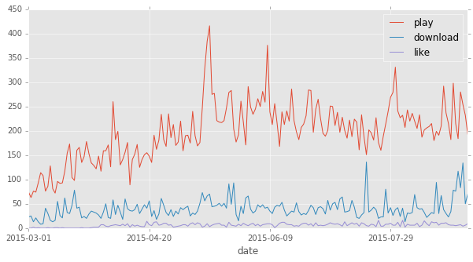

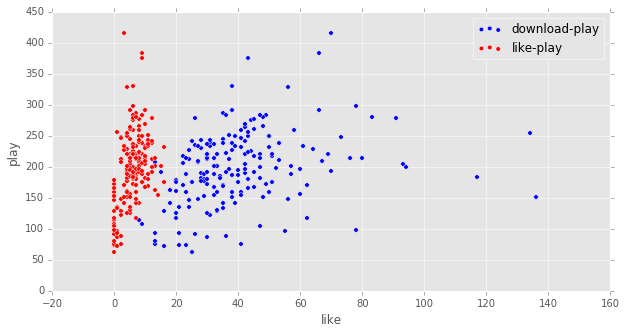

```python
a = df_artists[['date', 'play', 'download', 'like']][df_artists['artist_id'] == '0c80008b0a28d356026f4b1097041689']
a = a.set_index(['date'])

plt.figure()
a.plot(figsize = (10,5))
ax = a.plot.scatter(x = 'download', y = 'play', color = 'blue', label = 'download-play')
a.plot.scatter(figsize = (10,5), x = 'like', y = 'play', color = 'red', label = 'like-play', ax = ax)
```